# Part II - Presentation of Prosper Loan Data Exploration

## by Abdulwasiu Bamidele Popoola

## Investigation Overview

The goal of this work is to find out how some features affect the `LoanStatus` of borrowers in the Prosper Loan dataset. We also explored the relationship between some of the other features.

Some of the key inisghts gotten from this exploratory analysis include:

A borrowers `LoanStatus` is affected by the `BorrowerAPR`, `BorrowerRate`, `Term` etc.

There is a strong positve correlation between the `BorrowerAPR` and `BorrowerRate`.

The borrowers with `Current` loan status had longer `EmploymentStatusDuration`. Those who defaulted or past due dates had relatively smaller `EmploymentStatusDuration`.

Borrowers with `Current` or `Completed` loan status have relatively lower `BorrowerRate` while those who defaulted or were past due dates had higher `BorrowerRate`.

Most loans were for a `Term` of 36 months.

## Dataset Overview

This data set contains 113,937 loans with 81 features, including loan amount, borrower rate (or interest rate), current loan status, borrower income, and many others.

This data [dictionary](https://docs.google.com/spreadsheets/d/1gDyi_L4UvIrLTEC6Wri5nbaMmkGmLQBk-Yx3z0XDEtI/edit) explains the variables in the data set.

The following features may help support our investigation into the feature of interest (i.e. `LoanStatus`): I expect that most of the other features will have an effect on the feature of interest. Some of these features include: `Term`, `BorrowerAPR`, `BorrowerRate`, `Occupation`, `EmploymentStatus`, `EmploymentStatusDuration`, `IsBorrowerHomeowner`.

I had to select the main features by subsetting the main dataset for the above features I used for this exploratory work. In addition, had to set the order of charting for the nominal categorical variables but not for the ordinal variables. For some features, I also had to set the bin sizes (in some cases by using numpy arange function) in order to get a better view of the distribution of the variables. I also had to select some features from the entire dataset to narrow down my exploration on them.

The datatypes of some features was also changed to the appropriate datatype to enable proper exploration and visualization with the appropriate charts.

For some features with too many values, I focused on visualizing the top and bottom part of the observations.

Our newly created subset DataFrame, named `loans` is our working dataset which has 23 numeric, 3 datatime64[ns], 1 object, 2 bool, and 9 category datatypes.

Our feature of interest, `LoanStatus` is a categorical variable with 12 main categories of borrowers. However the four highest are: `Current` making up about 49%of total borrowers, `Completed` constituting about 33%, `Chargedoff` makine up 10% and `Defaulted` making up about 4% of total borrowers by `LoanStatus`.

## Visualization 1: Distribution of our feature of interest- `LoanStatus`

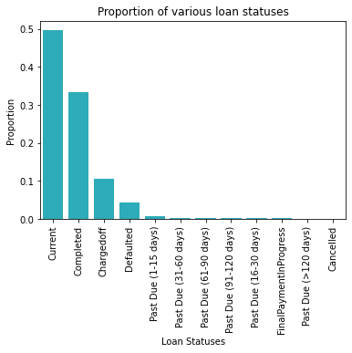

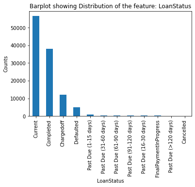

## Visualization 1: Relationship between `LoanStatus` and `BorrowerAPR`

Those with `Current` Loan Status have one of the relatively lowest mean `BorrowerAPR`. Those who defaulted or were past their paymemt due dates had higher `BorrowerAPR`. Thus the `BorrowerAPR` can be seen to affect the `LoanStatus` of borrowers.

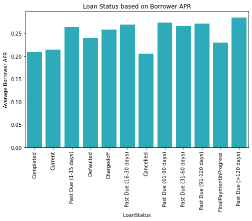

## Visualization 2: Relationship between `LoanStatus` and `BorrowerRate`

Borrowers with `Current` or `Completed` status have relatively lower `BorrowerRate`(interest rate) while those who defaulted or were past due dates had higher `BorrowerRate`.

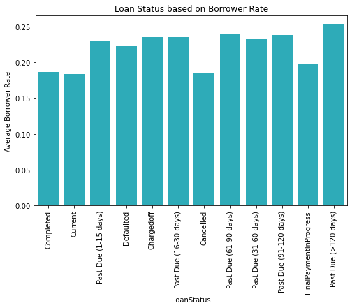

## Visualization 3: Relationship between `LoanStatus` and `Term`

Amongst all categories of `LoanStatus`, the commonest loan `Term` is 36 months, and particularly, amongst those borrowers with `Completed` and `Current` loan statuses. Amongst `Current` loan status borrowers, 60 months `Term` is the 2nd commnest.

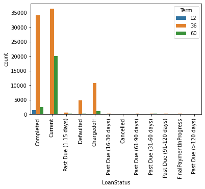

## Visualization 4: Relationship between `LoanStatus` and `AvailableBankcardCredit`

Those borrowers with `Completed` or `Current` `LoanStatus` have higher `AvailableBankcardCredit`. Those borrowers with status of `Past Due (>120 days)` had the least `AvailableBankcardCredit`.

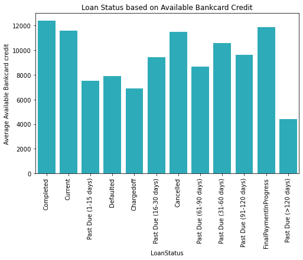

## Visualization 5: Relationship between `BorrowerAPR` and `BorrowerRate`

There is a positve correlation between the `BorrowerAPR` and `BorrowerRate`.

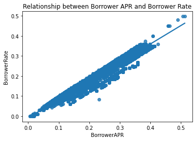

## Visualization 6: Relationship between `LoanStatus` and `EmploymentStatusDuration`

This distribution has a lot of observed outliers. The borrowers with `Current` loan status had longer `EmploymentStatusDuration`. Those who `Defaulted` or past due dates had relatively smaller `EmploymentStatusDuration`.

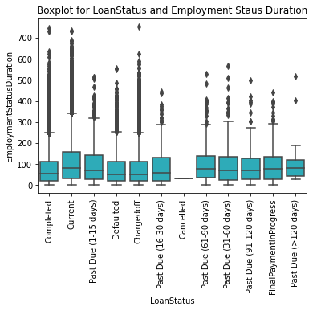

Those borrowers without homes had a higher `BorrowerRate`.

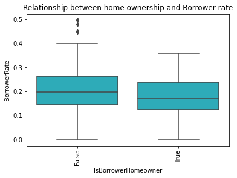

The 12 months loan term had the lowest median `BorrowerRate` while both the 36 and 60 months terms had about thesame median `BorrowerRate`.

The 36 months `Term` had the highest `BorrowerRate` with some even shown as outliers. It also had the lowest rate amongst the three terms.

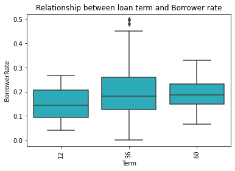

## Visualization 9: Relationship between `Term`, `IsBorrowerhomeowner` and `BorrowerRate`

Borrowers without homes have a higher `BorrowerRate` for thesame loan `Term`.

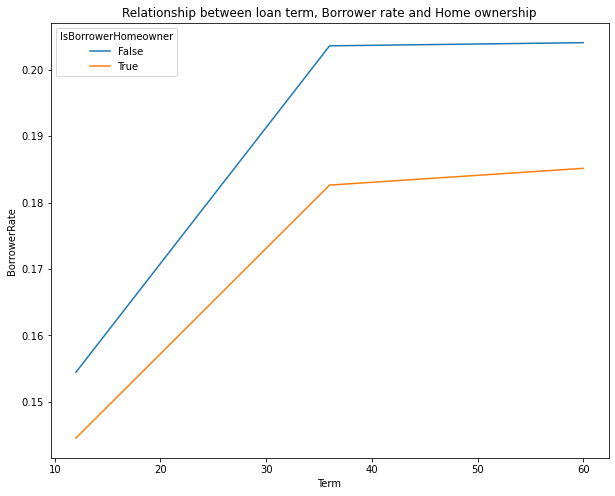

## Visualization 10: Relationship between `LoanStatus`, `Term` and `BorrowerAPR`

Those with `Term` of 12 months and `LoanStatus` of `Defaulted` had the highest `BorrowerAPR`. Amongst `Current` borrowers, there is no much difference in `BorrowerAPR` for all the three `Term`s

In addition we create a color dictionary which we shall assign to our categories. We can use the inbuilt color palette for Matplotlib, but I prefer to define my own for better control and ease of visualization interpretation.

```
Current       56576
Completed     38074
Chargedoff    11992
Defaulted      5018
Cancelled         5
Name: LoanStatus, dtype: int64
```

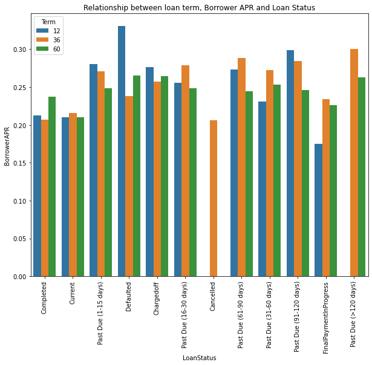

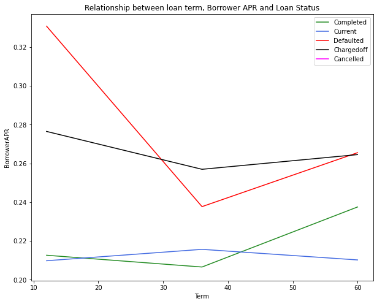

[figure not shown]

## Visualization 11: Relationship between `LoanStatus`, `Term` and `BorrowerRate`

Those with `Defaulted` status had the highest `BorrowerRate` for those with `Term` of 12 months.

For `Term` of 12 months, those who had the lowest `BorrowerRate` were those with `LoanStatus` of `FinalPaymentInProgress`.

There is a progressive increase in `LoanRate` for those with statuses of `Chargedoff`, `Completed`, and `Current` with increasing loan `Term`. Amongst the `Defaulted` group, there doesn't appear to be much difference in `BorrowerRate` across the three loan `Term`s.

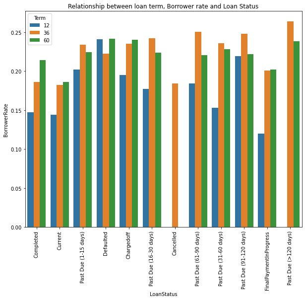

[output not shown]